Ficha del establecimiento

# Escuela De Párvulos Rayito De Luz

RBD **9446**Pedro Aguirre CerdaEscuela o liceo

82estudiantes matriculadosCorte Agosto 2026

Mujeres47,6%39 est.

Hombres52,4%43 est.

Chilenos/as87,8%72 est.

Extranjeros/as12,2%10 est.

Actualizada al 05-10-2026

💻Ver ficha completaVersión para computador, con mapas y gráficos interactivos. Pesa varios MB: mejor ábrela con wifi.

🏛️Identificación

## Identificación del establecimiento

Los datos de contacto y las características básicas del establecimiento, tal como están registrados en el Ministerio de Educación. **Si algo está mal o falta, escríbenos** y lo corregimos en la próxima actualización.

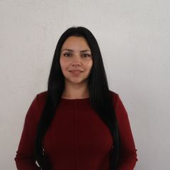

Director o directora

Stephanie Sofia Aranda Figueroa

**Nombre**

Escuela De Párvulos Rayito De Luz

**RBD**

9446

**Dirección**

Mariquina 3244 3244

**Comuna**

Pedro Aguirre Cerda

**Tipo**

Escuela o liceo

**Estado**

✅En funcionamiento

**Director/a**

Stephanie Sofia Aranda Figueroa

**Correo**

escuelarayitodeluz@slepsantarosa.cl

**Teléfono**

23965836

**Sitio web**

—

**Matrícula**

GRATUITO

**Sostenedor**

El sostenedor corresponde a una persona jurídica

**Orientación**

Orientación religiosa Laica

### Niveles que imparte

✓ 🧸 Educación Parvularia

### Vulnerabilidad del alumnado

Índice de vulnerabilidad (IVE)

—

Lo calcula JUNAEB y sirve para asignar programas de apoyo.

**Un IVE más alto significa más necesidad de apoyo**, no peor calidad. Se usa para decidir a qué establecimientos llegan primero los programas de alimentación, salud y becas.

### Apoyos profesionales al aprendizaje

✓ 🧩 Psicopedagogo/a✓ 🧠 Psicólogo/a✓ 👩‍🏫 Profesor/a de educación especial✓ 🤝 Asistente social✓ 🗣️ Fonoaudiólogo/a✓ ➕ Otro: TERAPEUTA OCUPACIONAL📚 Reforzamiento🧭 Orientador/a🎓 Orientación vocacional

### Infraestructura y atención a la diversidad

✓ 🖥️ Sala de informática📚 Biblioteca🔬 Laboratorio🏛️ Sala multiuso🌐 Computadores con internet💻 Computadores📽️ Sala audiovisual🏟️ Cancha deportiva🤾 Gimnasio♿ Accesibilidad NEE➕ Otra

✓ 🧩 Trastorno del espectro autista✓ 🗣️ Trastorno específico del lenguaje👁️ Discapacidad visual👂 Discapacidad auditiva🧠 Discapacidad intelectual🦽 Discapacidad motora💬 Trastornos de la comunicación📖 Dificultades de aprendizaje🎯 Déficit atencional📊 Funcionamiento intelectual limítrofe

Las etiquetas con ✓ son las que el establecimiento declaró en el directorio oficial; las grises no están marcadas.

### Jornada Escolar Completa (JEC)

Cursos con jornada completa

0

Cursos sin jornada completa

**Ver curso por curso**

| Grado | Cursos | Jornada |
| --- | --- | --- |
| Kínder | 3 | — Sin JEC |
| Pre-kínder | 3 | — Sin JEC |

Con **Jornada Escolar Completa** los estudiantes tienen más horas de clases al día y almuerzan en el establecimiento.

### Certificación ambiental (SNCAE)

El establecimiento no tiene certificación del Sistema Nacional de Certificación Ambiental de Establecimientos Educacionales (SNCAE).

### Concentración de alumnado prioritario

Concentración 2026

61,1%

▼14,85 pts

Porcentaje de estudiantes prioritarios reconocidos por el Mineduc.

0%100%

Concentración del establecimiento

Concentración 2025

75,9%

Resolución exenta

2026

Observación del Ministerio: **Mantienen ACAP**.

La **concentración de prioritarios** define cuánta Subvención Escolar Preferencial (SEP) recibe el establecimiento. Sobre 60 % da acceso a la asignación por concentración.

### Requisitos para postular

✓ 🎂 Cumplir la edad mínima✓ 📄 Certificado de nacimiento✓ ✍️ Firmar el proyecto educativo✓ ⚖️ Firmar el reglamento de convivencia✓ 👥 Entrevista con apoderados📊 Certificado de notas📝 Informe de personalidad🏠 Ficha de protección social🧪 Test de intereses♿ Informe de necesidades educativas📋 Examen de ingreso🎲 Sorteo💍 Certificado de matrimonio⛪ Certificado de bautismo⛪ Certificado de matrimonio religioso💰 Pago de postulación➕ Otro

Desde el Sistema de Admisión Escolar, los establecimientos públicos **no pueden seleccionar** por rendimiento ni por antecedentes socioeconómicos. Estos son los antecedentes administrativos que el establecimiento declara pedir.

**Equipo del SLEP que acompaña al establecimiento**

**Asesor/a territorial**

RUBÉN CORTEZ GALLARDO

**Correo UTP**

utp.escuelarayitodeluz@slepsantarosa.cl

**Correo Inspectoría**

inspectoria.escuelarayitodeluz@slepsantarosa.cl

🏫Matrícula

## Matrícula y asistencia

Cuántos estudiantes tiene el establecimiento, quiénes son y cuántos días van efectivamente a clases. **La asistencia es el porcentaje de días que los estudiantes asistieron** sobre los días en que estuvieron matriculados.

Matrícula · Agosto 2026

82

■0,0%

Variación desde el primer mes del año escolar.

1141.024

Este establecimientoPromedio del SLEP 333

Asistencia promedio

87,6%

Días asistidos sobre días matriculados.

76,5%89,9%

Este añoPromedio de años anteriores 82,7%

Cursos

6

Niveles

1

Matrícula regular

82

Estudiantes en la modalidad regular del establecimiento.

Matrícula no regular

0

Modalidades de adultos, reingreso o validación de estudios.

Matrícula mes a mes · 2026

Cuántos estudiantes había registrados al cierre de cada mes.

Asistencia mes a mes · 2026

Porcentaje de días asistidos sobre los días en que el estudiante estuvo matriculado.

Matrícula año a año

Matrícula del último mes de cada año escolar.

### Quiénes estudian acá

Por género

Hombres · 43Mujeres · 39

Por origen

Chilenos/as · 72Extranjeros/as · 10Nacionalizados/as · 0

Nacionalidades presentes

Número de estudiantes por país de nacimiento declarado.

🇨🇱 Chilena72

🇻🇪 Venezolana4

🇨🇴 Colombiana3

🇪🇨 Ecuatoriana1

🇵🇪 Peruana1

❔ Sin información1

Pueblos originarios

Estudiantes que declaran pertenecer a un pueblo originario.

🌿 Mapuche21

### Por nivel de enseñanza

Matrícula por nivel

🧸 Educación Parvularia82

Asistencia por nivel

La escala va de 0 % a 100 %.

🧸 Educación Parvularia87,6%

### Asistencia por grupo

Asistencia por género

Promedio ponderado por el número de estudiantes de cada grupo.

Hombres87,0%

Mujeres88,3%

Asistencia por origen

Chilenos/as88,8%

Extranjeros/as79,5%

Asistencia por nacionalidad

Solo los seis grupos con más estudiantes.

🇨🇱 Chilena88,8%

🇻🇪 Venezolana92,9%

🇨🇴 Colombiana42,9%

🇪🇨 Ecuatoriana100,0%

🇵🇪 Peruana95,2%

❔ Sin información100,0%

Asistencia por pueblo originario

🌿 Mapuche90,7%

**Ver el detalle curso por curso (6 cursos)**

| Curso | Matrícula | Asistencia % |
| --- | --- | --- |
| Pre-kínder A | 15 | 95,2 |
| Pre-kínder B | 16 | 87 |
| Pre-kínder C | 18 | 84,7 |
| Kínder A | 15 | 87,9 |
| Kínder B | 8 | 84,5 |
| Kínder C | 10 | 84,8 |

**Ver la matrícula año a año, con su variación**

| Periodo | Matrícula | Variación | Cambio |
| --- | --- | --- | --- |
| 2026 | 82 | −26,0 | −24,1% |
| 2025 | 108 | −44,0 | −28,9% |
| 2024 | 152 | +13,0 | +9,4% |
| 2023 | 139 | −6,0 | −4,1% |
| 2022 | 145 | −18,0 | −11,0% |
| 2019 | 163 | −2,0 | −1,2% |
| 2018 | 165 | −7,0 | −4,1% |
| 2017 | 172 | +14,0 | +8,9% |
| 2016 | 158 | — | — |

**Ver la asistencia año a año, con su variación**

| Periodo | Asistencia | Variación | Cambio |
| --- | --- | --- | --- |
| 2026 | 87,6% | +10,2 pts | +13,2% |
| 2025 | 77,4% | −1,1 pts | −1,4% |
| 2024 | 78,5% | −1,4 pts | −1,8% |
| 2023 | 79,9% | −5,1 pts | −6,0% |
| 2022 | 85,0% | −1,5 pts | −1,7% |
| 2019 | 86,5% | −2,4 pts | −2,7% |
| 2018 | 88,9% | +5,5 pts | +6,6% |
| 2017 | 83,4% | +1,1 pts | +1,3% |
| 2016 | 82,3% | — | — |

La matrícula se cuenta al cierre de cada mes, así que los cambios durante el año reflejan traslados y retiros. Corte usado: **Agosto 2026**.

🤝Vida escolar

## Vida escolar y comunidad

Qué actividades ofrece el establecimiento fuera de las clases, cómo se organiza con las familias y quiénes representan a la comunidad. **Las etiquetas con ✓ son las que el establecimiento declaró** en el directorio oficial del Ministerio; las grises no están marcadas.

### Talleres y actividades para estudiantes

✓ 🤝 Convivencia✓ 🌟 Vida sana🧭 Orientación🚫 Prevención drogas❤️ Educación sexual🌱 Medio ambiente🫂 Acción social✝️ Pastoral➕ Otra

Actividades de formación: orientación, convivencia, prevención y vida sana.

Talleres de arte, cultura y tecnología fuera del horario de clases.

✓ ➕ Otro: TALLER DE PSICOMOTRICIDAD⚽ Fútbol🥅 Baby fútbol🏃 Atletismo🏐 Vóleibol🏀 Básquetbol🏊 Natación🤸 Gimnasia🎾 Tenis🏓 Tenis de mesa♟️ Ajedrez

Disciplinas deportivas que ofrece el establecimiento.

### Trabajo con las familias

✓ 👪 Talleres de formación🎉 Actividades de integración📈 Perfeccionamiento➕ Otra

✓ 📒 Libreta de comunicaciones✓ 🗣️ Consejo escolar✓ 📄 Reuniones generales✓ 👥 Entrevistas individuales🌐 Web y redes sociales➕ Otro

Por dónde el establecimiento se comunica con apoderados y apoderadas.

### Organizaciones de la comunidad

**Centro de Padres**

Constituido

**Personalidad jurídica**

Vigente

**Última elección de directiva**

**Centro de Estudiantes**

—

**Representante del sostenedor en el Consejo Escolar**

Osman Yeomans Jiménez

**Acompañamiento del Consejo Escolar**

Osman Yeomans Jiménez

Para contactar al centro de padres o al centro de estudiantes, escribe al establecimiento: sus datos están más arriba.

El **Consejo Escolar** es la instancia donde se juntan dirección, docentes, asistentes, apoderados y estudiantes para conversar sobre la marcha del establecimiento.

### Normativa y conectividad

**Uso de uniforme**

Uniforme propio del establecimiento

**Tipo de conexión**

ADSL o cable coaxial

**Velocidad de internet**

Sin información

🧭Gestión

## Instrumentos de gestión: PEI y PME

El **PEI** dice quién quiere ser el establecimiento: su misión, su visión y sus sellos. El **PME** dice qué va a hacer este año para lograrlo, con responsables y presupuesto. Son los dos documentos que ordenan el trabajo.

### Proyecto Educativo Institucional (PEI)

**Misión**

Somos una escuela de tradición familiar, que busca fortalecer y desarrollar integralmente en los niños las diversas habilidades, capacidades, intereses y valores, en las dimensiones sociales, afectivas y académicas. Valoramos la riqueza de la diversidad, la solidaridad, reconocemos la importancia de comunicarnos asertivamente en un clima de armonía, considerando a las personas de manera empática, opinando, reflexionando y trabajando colaborativamente en compromiso y respeto por su entorno.

**Visión**

Contribuiremos en el proceso formativo integral de los niños basándonos en un marco afectivo y de buen trato, para que tengan la oportunidad de crecer en armonía. Construyendo así una comunidad escolar inclusiva, capaz de generar un espacio acogedor y participativo para todos los estamentos, aprendiendo a convivir en la riqueza de la diversidad de género, étnica, cultural, socioeconómica, aspectos físicos, psicológicos y ritmos de aprendizajes.

### Énfasis declarados, en orden de prioridad

**1º**

Desarrollo integral

**2º**

Inclusivo

**3º**

Excelencia académica

### Documentos oficiales

[📘Proyecto Educativo](https://wwwfs.mineduc.cl/Archivos/infoescuelas/documentos/9446/ProyectoEducativo9446.pdf)[⚖️Reglamento de Convivencia](https://wwwfs.mineduc.cl/Archivos/infoescuelas/documentos/9446/ReglamentodeConvivencia9446.pdf)[📊Reglamento de Evaluación](https://wwwfs.mineduc.cl/Archivos/infoescuelas/documentos/9446/ReglamentoDeEvaluacion9446.pdf)

### Plan de Mejoramiento Educativo (PME)

Acciones comprometidas

15

Inversión total del plan

$ 73.634.705

Dimensiones cubiertas

4

Acciones por dimensión

Las cuatro dimensiones del PME: gestión pedagógica, liderazgo, convivencia y recursos.

Gestión Pedagógica5

Convivencia Escolar4

Gestión de Recursos4

Liderazgo2

Quién lidera las acciones

Los cinco responsables con más acciones a cargo.

Director9

Encargado de convivencia2

Jefe técnico2

Coordinadora PIE1

Sostenedor1

De dónde sale el financiamiento

Monto comprometido por fuente de recursos.

sep$ 73.634.705

**Ver las 15 acciones del plan**

| Acción | Dimensión | Responsable | Monto |
| --- | --- | --- | --- |
| Acompañamiento y retroalimentación al aula | Gestión Pedagógica | Jefe técnico | $ 0 |
| Estrategias efectivas para el aprendizaje | Gestión Pedagógica | Director | $ 3.300.000 |
| Asesoría técnica y actividad de formación, información y orientación para las comunidades educativas | Gestión Pedagógica | Director | $ 0 |
| Servicio de Plataforma Educativa | Gestión Pedagógica | Jefe técnico | $ 979.013 |
| Plan de transición educativa (DECRETO 373) | Gestión Pedagógica | Director | $ 320.000 |
| Contratación de Profesionales para fortalecer la gestión de soporte para los procesos educativos | Liderazgo | Sostenedor | $ 6.952.222 |
| Resultados educativos | Liderazgo | Director | $ 870.348 |
| Bienestar integral | Convivencia Escolar | Encargado de convivencia | $ 150.000 |
| Vínculo escuela, familia y comunidad | Convivencia Escolar | Encargado de convivencia | $ 2.363.566 |
| Asistencia y resguardo de las trayectorias educativas (Dupla Psicosocial) | Convivencia Escolar | Director | $ 30.000.000 |
| Servicio de transporte escolar para salidas pedagógicas y/o actividades extraescolares | Convivencia Escolar | Director | $ 1.654.844 |
| Servicio de equipos multicopiadores para el Apoyo Pedagógico | Gestión de Recursos | Director | $ 2.417.989 |
| Adquisición de Material Escolar para el Apoyo al Aprendizaje | Gestión de Recursos | Director | $ 1.442.221 |
| Contratación de Docentes y/o Asistentes de la Educación para Apoyo Pedagógico | Gestión de Recursos | Director | $ 12.700.000 |
| Profesionales para el Apoyo a Estudiantes con Necesidades Educativas Especiales | Gestión de Recursos | Coordinadora PIE | $ 10.484.502 |

**Ver plazos y estado de ejecución de cada acción**

| Acción | Inicio | Término | Nivel de ejecución |
| --- | --- | --- | --- |
| Acompañamiento y retroalimentación al aula | 03/3/2025 | 31/12/2025 | Implementado (100%) |
| Estrategias efectivas para el aprendizaje | 05/3/2025 | 31/12/2025 | Implementado (100%) |
| Asesoría técnica y actividad de formación, información y orientación para las comunidades educativas | 05/3/2025 | 31/12/2025 | Implementado (100%) |
| Servicio de Plataforma Educativa | 03/3/2025 | 31/12/2025 | Implementado (100%) |
| Plan de transición educativa (DECRETO 373) | 04/3/2025 | 31/12/2025 | Implementado (100%) |
| Contratación de Profesionales para fortalecer la gestión de soporte para los procesos educativos | 04/3/2025 | 31/12/2025 | Implementado (100%) |
| Resultados educativos | 04/3/2025 | 31/12/2025 | Implementado (100%) |
| Bienestar integral | 04/3/2025 | 31/12/2025 | Implementado (100%) |
| Vínculo escuela, familia y comunidad | 04/3/2025 | 31/12/2025 | Implementado (100%) |
| Asistencia y resguardo de las trayectorias educativas (Dupla Psicosocial) | 03/3/2025 | 31/12/2025 | Implementado (100%) |
| Servicio de transporte escolar para salidas pedagógicas y/o actividades extraescolares | 03/3/2025 | 31/12/2025 | Implementado (100%) |
| Servicio de equipos multicopiadores para el Apoyo Pedagógico | 03/3/2025 | 31/12/2025 | Implementado (100%) |
| Adquisición de Material Escolar para el Apoyo al Aprendizaje | 03/3/2025 | 31/12/2025 | Implementado (100%) |
| Contratación de Docentes y/o Asistentes de la Educación para Apoyo Pedagógico | 03/3/2025 | 31/12/2025 | Implementado (100%) |
| Profesionales para el Apoyo a Estudiantes con Necesidades Educativas Especiales | 03/3/2025 | 31/12/2025 | Implementado (100%) |

**Ver estrategia, programa y medios de verificación**

[output not shown]

**Ver la descripción completa y la justificación de cada acción**

| Acción | Qué se hace | Por qué |
| --- | --- | --- |
| Acompañamiento y retroalimentación al aula | Implementar ciclos mensuales de observación entre pares, donde los docentes puedan asistir a clases de sus colegas para identificar prácticas pedagógicas innovadoras, para luego realizar sesiones de r… | El nivel de implementación está dentro del curso adecuado en relación a las fechas programadas. |
| Estrategias efectivas para el aprendizaje | Utilizar metodologías basadas en proyectos, u otros similares que contemplen salidas pedagógicas u otras actividades con los estudiantes, en ambientes lúdicos y pedagógicamente intencionados para el a… | El nivel de implementación está dentro del curso adecuado en relación a las fechas programadas. |
| Asesoría técnica y actividad de formación, información y orientación para las comunidades educativas | Capacitaciones para docentes y asistentes de la educación con temáticas relacionadas en: Desarrollo profesional docente Herramientas digitales para la educación Temáticas en convivencia escolar | El nivel de implementación está dentro del curso adecuado en relación a las fechas programadas. |
| Servicio de Plataforma Educativa | La plataforma educativa es una herramienta digital que facilita la planificación, implementación y seguimiento con un enfoque pedagógico. Su propósito es fortalecer la gestión curricular y didáctica, … | El nivel de implementación está dentro del curso adecuado en relación a las fechas programadas. |
| Plan de transición educativa (DECRETO 373) | Plan de acción que tiene como propósito fundamental promover y resguardar el traspaso entre el nivel NT2 y 1º Básico. | El nivel de implementación está dentro del curso adecuado en relación a las fechas programadas. |
| Contratación de Profesionales para fortalecer la gestión de soporte para los procesos educativos | Contratación de profesionales especializados en distintas áreas para fortalecer la gestión de los procesos educativos en los establecimientos educacionales, optimizando la planificación, seguimiento y… | El nivel de implementación está dentro del curso adecuado en relación a las fechas programadas. |
| Resultados educativos | Analizar los resultados educativos de manera sistemática y continua que permita la toma de decisiones oportunas y pertinentes al contexto educativo, asegurando el desarrollo integral de nuestros estud… | El nivel de implementación está dentro del curso adecuado en relación a las fechas programadas. |
| Bienestar integral | Se realizan actividades de orientación, encuentros o instancias de sensibilización de manera semestral, que promuevan el bienestar físico, emocional y social de toda la comunidad educativa. | El nivel de implementación está dentro del curso adecuado en relación a las fechas programadas. |
| Vínculo escuela, familia y comunidad | Organizar jornadas que permitan afianzar la sana convivencia y comunicación entre la escuela, las familias y comunidad, donde todos se sientan valorados y comprometidos con el bienestar de los niños y… | El nivel de implementación está dentro del curso adecuado en relación a las fechas programadas. |
| Asistencia y resguardo de las trayectorias educativas (Dupla Psicosocial) | Contratación de especialistas del área psicosocial, como trabajadores sociales, psicólogos y coordinadores, para fortalecer el acompañamiento integral de los y las estudiantes y garantizar su continui… | El nivel de implementación está dentro del curso adecuado en relación a las fechas programadas. |
| Servicio de transporte escolar para salidas pedagógicas y/o actividades extraescolares | El servicio de transporte escolar para salidas pedagógicas y actividades extraescolares facilita el acceso de los y las estudiantes a experiencias de aprendizaje fuera del aula, enriqueciendo su forma… | El nivel de implementación está dentro del curso adecuado en relación a las fechas programadas. |
| Servicio de equipos multicopiadores para el Apoyo Pedagógico | Contratación de un servicio de multicopiado para la impresión de material didáctico de calidad, con el objetivo de fortalecer los procesos de enseñanza y aprendizaje de los estudiantes. Este servicio … | El nivel de implementación está dentro del curso adecuado en relación a las fechas programadas. |
| Adquisición de Material Escolar para el Apoyo al Aprendizaje | Adquisición de material escolar e insumos de material pedagógico para garantizar que todos los estudiantes cuenten con los recursos necesarios para su desarrollo académico, fortaleciendo el acceso equ… | El nivel de implementación está dentro del curso adecuado en relación a las fechas programadas. |
| Contratación de Docentes y/o Asistentes de la Educación para Apoyo Pedagógico | La contratación de docentes y asistentes de la educación tiene como objetivo fortalecer y apoyar los procesos pedagógicos, brindando un acompañamiento especializado a los estudiantes. Estos profesiona… | El nivel de implementación está dentro del curso adecuado en relación a las fechas programadas. |
| Profesionales para el Apoyo a Estudiantes con Necesidades Educativas Especiales | Contratación de asistentes de la educación con el propósito de brindar apoyo especializado a estudiantes que presentan necesidades educativas especiales, incluyendo aquellos con diagnóstico de espectr… | El nivel de implementación está dentro del curso adecuado en relación a las fechas programadas. |

🏆SNED

## SNED · Sistema Nacional de Evaluación del Desempeño

El SNED evalúa cada dos años el desempeño de los establecimientos municipales y particulares subvencionados. Mira **seis factores**: efectividad, superación, igualdad de oportunidades, iniciativa, integración y mejoramiento.

⚪No seleccionado

Índice SNED del establecimiento

Va de 0 a 100 y resume los seis factores que evalúa el sistema.

Los seis factores, uno por uno

Cada factor va de 0 a 100. Los de arriba pesan más en el índice final.

Efectividad47,7%

Superación50,4%

Igualdad de oportunidades96,0%

Iniciativa80,9%

Integración82,5%

Mejoramiento100,0%

**¿Cuánto pesa cada factor?**

| Factor | Puntaje | Peso en el índice (%) |
| --- | --- | --- |
| Efectividad | 47,7 | 37 |
| Superación | 50,4 | 28 |
| Igualdad de oportunidades | 96 | 22 |
| Iniciativa | 80,9 | 6 |
| Integración | 82,5 | 5 |
| Mejoramiento | 100 | 2 |

El SNED premia con un bono a los equipos de los establecimientos con mejor desempeño dentro de un grupo de escuelas parecidas. **No es una nota**: compara con establecimientos de condiciones similares, no con todo Chile.

💼Ocupación

## Ocupación de cupos

Cuántos de los cupos que el establecimiento ofreció están efectivamente ocupados. **Se calcula dividiendo la matrícula actual por los cupos declarados** en el Sistema de Admisión Escolar (SAE).

📭**No hay cupos SAE registrados para este establecimiento.**Los cupos del Sistema de Admisión Escolar se publican una vez al año.

♿PIE

## Programa de Integración Escolar (PIE)

Cuántos estudiantes reciben apoyos del PIE y qué tipo de apoyo necesitan. Las **necesidades permanentes** acompañan toda la trayectoria escolar; las **transitorias** requieren apoyo por un tiempo determinado.

Estudiantes en PIE · 2026

10

Se cuenta cada estudiante una sola vez.

0,0%40,0%

Porcentaje de la matrícula

NEE permanentes

1

Acompañan toda la trayectoria escolar.

NEE transitorias

9

Requieren apoyo por un tiempo acotado.

Sobre la matrícula

12,2%

Tipo de necesidad educativa

NEE permanentes · 1NEE transitorias · 9

Por género

Hombres · 5Mujeres · 5

Diagnósticos más frecuentes

Los ocho diagnósticos con más estudiantes.

Trastorno del Lenguaje9

Trastorno del Espectro Autista1

En qué cursos están

Kínder10

Por nivel de enseñanza

Educación Parvularia10

**Ver el cruce entre género y tipo de necesidad**

| Genero | PERMANENTE | TRANSITORIO |
| --- | --- | --- |
| Femenino | 1 | 4 |
| Masculino | 0 | 5 |

**Ver el cruce entre género y los diagnósticos más frecuentes**

| Genero | Trastorno del Espectro Autista | Trastorno del Lenguaje |
| --- | --- | --- |
| Femenino | 1 | 4 |
| Masculino | 0 | 5 |

**Ver todos los diagnósticos registrados**

| Diagnóstico | Tipo de NEE | Estudiantes |
| --- | --- | --- |
| Trastorno del Lenguaje | TRANSITORIO | 9 |
| Trastorno del Espectro Autista | PERMANENTE | 1 |

### Postulaciones al programa, por período

Estudiantes por año y período

El período **Regular** es la postulación anual; **Extraordinario** y **Excepcionalidad** son cupos que se abren después.

2026 · Regular35

2025 · Regular37

2024 · Regular + Excepcionalidad39

**Ver el detalle por año, período y tipo de necesidad**

| Año | Período | Tipo de NEE | Estudiantes |
| --- | --- | --- | --- |
| 2.026 | Regular | PERMANENTE | 5 |
| 2.026 | Regular | TRANSITORIO | 30 |
| 2.025 | Regular | PERMANENTE | 7 |
| 2.025 | Regular | TRANSITORIO | 30 |
| 2.024 | Regular + Excepcionalidad | PERMANENTE | 9 |
| 2.024 | Regular + Excepcionalidad | TRANSITORIO | 30 |

Evolución del programa

Fuente: base territorial del Área de Inclusión Educativa del SLEP.

El PIE entrega apoyos dentro del aula a estudiantes con necesidades educativas especiales. **Estar en PIE no es un diagnóstico permanente**: muchas necesidades son transitorias y se superan con apoyo.

🔄Retiros

## Retiros y movilidad estudiantil

Cuántos estudiantes se retiraron del establecimiento, cuándo y hacia dónde. **Lo importante es saber si volvieron a matricularse en otra parte**: quienes no lo hicieron son los casos que hay que buscar.

Retiros en 2026

4

Equivale al 4,9% de la matrícula actual.

Ya están en otro establecimiento

1

Se confirmó matrícula posterior.

Sin matrícula vigente

1

Requieren seguimiento: pueden estar fuera del sistema.

Pendiente en SIGE

2

Todavía sin información de destino.

En qué meses se producen

Tipo de movimiento

Sin matrícula2

Cambio a otro EE fuera del SLEP1

Colisión dentro del mismo establecimiento1

A qué establecimientos se van

Los seis destinos más frecuentes.

Sin destino informado2

Escuela De Párvulos Rayito De Luz1

Nuevo Colegio Part. De Cartagena1

Desde qué cursos

Pre-kínder3

Kínder1

Qué tipo de establecimiento eligieron

Dependencia del establecimiento de destino.

Sin Matrícula2

Mismo Slep1

Particular Subvencionado1

A qué comunas se fueron

Sin información2

Cartagena1

Pedro Aguirre Cerda1

**Ver todos los destinos, uno por uno**

| Establecimiento | Comuna | Dependencia | Estudiantes |
| --- | --- | --- | --- |
| Sin destino informado | — | Sin Matrícula | 2 |
| Escuela De Párvulos Rayito De Luz | Pedro Aguirre Cerda | Mismo Slep | 1 |
| Nuevo Colegio Part. De Cartagena | Cartagena | Particular Subvencionado | 1 |

Un retiro no siempre es una pérdida: muchas veces la familia se cambia de comuna. Lo que sí requiere seguimiento son los estudiantes **sin matrícula vigente** en ningún otro establecimiento.

📚Resultados

## Resultados educativos

Cómo les fue a los estudiantes en sus notas y cuántos pasaron de curso. El **promedio general** va de 1,0 a 7,0 y la **tasa de aprobación** es el porcentaje de estudiantes que fue promovido al curso siguiente.

📭**Todavía no hay resultados de rendimiento para este establecimiento.**El rendimiento se cierra al final de cada año escolar.

📐SIMCE

## SIMCE

El SIMCE es la prueba que aplica la Agencia de Calidad para saber cuánto aprendieron los estudiantes en Lectura y Matemática. Además del puntaje, muestra **cuántos estudiantes quedaron en cada nivel de aprendizaje**: Insuficiente, Elemental o Adecuado.

📭**Este establecimiento no tiene resultados SIMCE publicados.**El SIMCE se rinde en cursos determinados y no todos los años.

🌱IDPS

## Indicadores de Desarrollo Personal y Social

Los IDPS miden cosas que no salen en una prueba: si los estudiantes se sienten capaces de aprender, si el ambiente es sano, si participan y si tienen hábitos saludables. **Van de 0 a 100** y se comparan con establecimientos de condiciones parecidas.

📭**Este establecimiento no tiene resultados IDPS publicados.**Los IDPS se miden junto con el SIMCE, en los mismos cursos.

📄DIA

## DIA de cierre

El Diagnóstico Integral de Aprendizajes (DIA) se aplica al cierre del año para ver qué aprendieron los estudiantes. **No pone notas**: clasifica a cada estudiante en un nivel de logro para orientar el trabajo del año siguiente.

📭**Este establecimiento no rindió el DIA de cierre, o los resultados aún no llegan.**El DIA es una evaluación de aplicación voluntaria que entrega el Ministerio.

📈PAES

## PAES

La PAES es la prueba que se rinde para postular a la educación superior. Aquí verás **cuántos estudiantes la rindieron** y qué puntaje promedio obtuvieron, comparado con el promedio del SLEP y el nacional.

📭**Este establecimiento no tiene resultados PAES.**La PAES la rinden solo los establecimientos con enseñanza media.

🎓Ed. superior

## Tránsito a la educación superior

Qué pasó con los estudiantes después de egresar: cuántos entraron a una universidad, instituto profesional o centro de formación técnica, y qué estudian. **Se mira el año inmediatamente siguiente al egreso**.

📭**Todavía no hay seguimiento de egresados para este establecimiento.**El seguimiento se construye cruzando los egresados con las matrículas de educación superior.

🛠️Técnico profesional

## Técnico profesional: especialidades y titulación

Qué especialidades técnicas ofrece el establecimiento, cómo les va a los estudiantes de cada una y cuántos alcanzan el **título técnico de nivel medio** después de hacer su práctica profesional.

📭**Este establecimiento no imparte educación técnico-profesional.**Solo entrega formación humanístico-científica o de enseñanza básica.

👔Funcionarios

## Funcionarios del establecimiento

Cuántas personas trabajan en el establecimiento y en qué. La **dotación estable** son quienes tienen contrato titular o a contrata; los **reemplazos** cubren licencias y permisos, así que un número alto puede indicar rotación.

Corte: **Mayo de 2026**.

Funcionarios y funcionarias

29

Personas distintas con contrato vigente.

Dotación estable

28

Titulares y a contrata, sin contar reemplazos.

En reemplazo

1

Es el 3,4% de la dotación.

Jornada promedio

35,2hrs

Horas semanales contratadas.

Docentes y asistentes de la educación

ASISTENTE DE LA EDUCACION17

DOCENTE12

Por función

Las ocho funciones con más personas.

EDUCADORA DE PARVULOS9

TECNICOS EN PARVULOS8

PROFESIONALES Y TECNICOS DE APOYO (PIE/SEP/SALUD)6

AUXILIARES DE SERVICIO3

DIRECTIVOS1

DIRECTORES1

DOCENTES1

Composición de la dotación

Docentes y asistentes de la educación, estables y en reemplazo.

Asistente estable · 17Docente estable · 11Docente en reemplazo · 1

Dotación mes a mes · 2026

Número de contratos vigentes en cada mes.

Dotación mes a mes por categoría

Asistente estableDocente en reemplazoDocente estable

**Ver el detalle por cargo (12 combinaciones)**

| Cargo o función | Tipo de hora | Personas | Jornada (hrs) |
| --- | --- | --- | --- |
| TECNICOS EN PARVULOS | TITULAR | 6 | 32,3 |
| EDUCADORA DE PARVULOS | CONTRATA | 5 | 35 |
| PROFESIONALES Y TECNICOS DE APOYO (PIE/SEP/SALUD) | TITULAR | 4 | 39,5 |
| AUXILIARES DE SERVICIO | TITULAR | 3 | 44 |
| EDUCADORA DE PARVULOS | TITULAR | 3 | 35 |
| PROFESIONALES Y TECNICOS DE APOYO (PIE/SEP/SALUD) | CONTRATA | 2 | 18 |
| DIRECTIVOS | CONTRATA | 1 | 44 |
| DIRECTORES | TITULAR | 1 | 30 |
| DOCENTES | CONTRATA | 1 | 38 |
| EDUCADORA DE PARVULOS | REEMPLAZO | 1 | 35 |
| TECNICOS EN PARVULOS | CODIGO DEL TRABAJO | 1 | 44 |
| TECNICOS EN PARVULOS | CONTRATA | 1 | 30 |

👩‍🏫Carrera docente

## Desarrollo profesional docente

En qué tramo de la Carrera Docente están los profesores y profesoras del establecimiento. Los tramos van de **Acceso** (quienes recién empiezan) a **Experto II**, y dependen de la experiencia y de la evaluación docente.

Corte: **Mayo de 2026**.

Docentes

En reemplazo

Sin encasillar

0

Es el 0,0% del cuerpo docente.

0%100%

Porcentaje sin encasillar

Docentes por tramo de la Carrera Docente

Los tramos van de Acceso (recién iniciados) a Experto II.

Acceso1

El tramo lo asigna el Sistema de Desarrollo Profesional Docente según la experiencia y los resultados de la evaluación. **Estar sin encasillar no es una falta**: suele pasar con quienes recién ingresan o están en proceso de evaluación.

🏢Convenios

## Convenios y uso de espacios

Qué organizaciones externas usan las instalaciones del establecimiento fuera del horario de clases, para qué y hasta cuándo.

📭**No hay convenios de uso de espacios registrados.**Se registran acá los acuerdos con clubes, juntas de vecinos u otras organizaciones que usan las instalaciones.

📣Denuncias

## Denuncias y reclamos

Los reclamos que las familias y la comunidad presentaron sobre el establecimiento, por dos vías: **directamente al SLEP** o ante la **Superintendencia de Educación**, que es el organismo fiscalizador.

### Denuncias recibidas por el SLEP

No hay denuncias internas registradas para este establecimiento.

### Denuncias ante la Superintendencia de Educación

No hay denuncias ante la Superintendencia para este establecimiento.

### Procesos administrativos

No hay procesos administrativos asociados a este establecimiento.

Una denuncia **no es una sanción**: es un reclamo que se investiga. Muchas se cierran sin encontrar falta. Lo que importa es que exista el canal y que los casos se tramiten.

👮Seguridad

## Robos y delitos

Los robos y daños que ha sufrido el establecimiento, cuándo ocurrieron y cuánto costaron. **Sirve para decidir dónde reforzar la seguridad**: cámaras, cierres perimetrales o rondas.

Incidentes en 2026

1

Especies sustraídas

$ 0

Daños a la propiedad

$ 0

Pérdida total

$ 0

Con denuncia policial

1

De 1 incidentes.

Unidad policial más frecuente

51° Comisaria de Pedro Aguirre Cerda

En qué meses ocurrieron

En qué horario

Sin registro1

Tipo de incidente

Robo en lugar no habitado1

**Ver los incidentes uno por uno**

| Fecha | Horario | Especies | Total |
| --- | --- | --- | --- |
| 24-06-2026 | — | — | $ 0 |

| Fecha | Especies |
| --- | --- |
| 24-06-2026 | 11 reposiciones de alimentacion de agua de los wc, 11 llaves de angulares y conexion de estanque, 18 monomandos de lavamanos y accesorios |

Los montos son el avalúo declarado por el establecimiento al informar el incidente. Esta información permite al SLEP **priorizar medidas de seguridad** donde más se necesitan.

📍Ubicación

## Ubicación y entorno

Dónde está el establecimiento, desde dónde llegan sus estudiantes y cómo es el barrio que lo rodea. **Toca el botón para abrir la ubicación** en la aplicación de mapas de tu teléfono.

**Dirección**

Mariquina 3244 3244

**Comuna**

Pedro Aguirre Cerda

**Región**

RM

**Zona**

Urbana

**Latitud**

-33,48273

**Longitud**

-70,67844

[📍Abrir en Google Maps](https://www.google.com/maps/search/?api=1&query=-33.48273,-70.67844)

### Dónde viven los estudiantes

📭**No hay direcciones geolocalizadas de estudiantes.**Se necesita el directorio de domicilios del año en curso.

### El barrio alrededor del establecimiento

Niños y jóvenes en la comuna

18.578

Personas de 0 a 17 años según el Censo 2024.

De 0 a 5 años

5.055

De 6 a 13 años

8.974

De 14 a 17 años

4.549

Población migrante en la comuna

9,3%

8.769 personas de 94.610 habitantes.

0%50%

Porcentaje de la comuna

Escolaridad promedio

9,3años

Años de estudio de los mayores de 18 años.

Población en edad escolar de la comuna

Censo 2024, 1.077 manzanas de Pedro Aguirre Cerda.

0 a 5 años5.055

6 a 13 años8.974

14 a 17 años4.549

Estos son datos del **Censo 2024 de toda la comuna**, no del establecimiento. Sirven para dimensionar cuántos niños y jóvenes viven en el territorio.

Esta es la versión para celular, con lo esencial. La **ficha completa** tiene todas las secciones, los gráficos interactivos y los mapas; se ve mejor en un computador.

Ver ficha completa